# Part 1

Author

Albert Rapp

Published

June 19, 2024

# Part I

## Lesson 1

Learning about the mechanics of wrangling data. Particularly `mutate()` and `summarise()` functions in an efficient manner of the databases to be used: penguins and ames.

```r
library(palmerpenguins)
library(tidyverse)
library(modeldata)
library(janitor)
library(skimr)

ames <- ames
penguins <- penguins
```

```r
dim(penguins)
```

[output not shown]

```r
palmerpenguins::penguins |>
  skimr::skim()
```

Data summary

| Name | palmerpenguins::penguins |
| --- | --- |
| Number of rows | 344 |
| Number of columns | 8 |
| _______________________ |  |
| Column type frequency: |  |
| factor | 3 |
| numeric | 5 |
| ________________________ |  |
| Group variables | None |

**Variable type: factor**

| skim_variable | n_missing | complete_rate | ordered | n_unique | top_counts |
| --- | --- | --- | --- | --- | --- |
| species | 0 | 1.00 | FALSE | 3 | Ade: 152, Gen: 124, Chi: 68 |
| island | 0 | 1.00 | FALSE | 3 | Bis: 168, Dre: 124, Tor: 52 |
| sex | 11 | 0.97 | FALSE | 2 | mal: 168, fem: 165 |

**Variable type: numeric**

| skim_variable | n_missing | complete_rate | mean | sd | p0 | p25 | p50 | p75 | p100 | hist |
| --- | --- | --- | --- | --- | --- | --- | --- | --- | --- | --- |
| bill_length_mm | 2 | 0.99 | 43.92 | 5.46 | 32.1 | 39.23 | 44.45 | 48.5 | 59.6 | ▃▇▇▆▁ |
| bill_depth_mm | 2 | 0.99 | 17.15 | 1.97 | 13.1 | 15.60 | 17.30 | 18.7 | 21.5 | ▅▅▇▇▂ |
| flipper_length_mm | 2 | 0.99 | 200.92 | 14.06 | 172.0 | 190.00 | 197.00 | 213.0 | 231.0 | ▂▇▃▅▂ |
| body_mass_g | 2 | 0.99 | 4201.75 | 801.95 | 2700.0 | 3550.00 | 4050.00 | 4750.0 | 6300.0 | ▃▇▆▃▂ |
| year | 0 | 1.00 | 2008.03 | 0.82 | 2007.0 | 2007.00 | 2008.00 | 2009.0 | 2009.0 | ▇▁▇▁▇ |

We can apply the skim function to the ames database

```r
modeldata::ames |>
  skimr::skim()
```

Data summary

| Name | modeldata::ames |
| --- | --- |
| Number of rows | 2930 |
| Number of columns | 74 |
| _______________________ |  |
| Column type frequency: |  |
| factor | 40 |
| numeric | 34 |
| ________________________ |  |
| Group variables | None |

**Variable type: factor**

| skim_variable | n_missing | complete_rate | ordered | n_unique | top_counts |
| --- | --- | --- | --- | --- | --- |
| MS_SubClass | 0 | 1 | FALSE | 16 | One: 1079, Two: 575, One: 287, One: 192 |
| MS_Zoning | 0 | 1 | FALSE | 7 | Res: 2273, Res: 462, Flo: 139, Res: 27 |
| Street | 0 | 1 | FALSE | 2 | Pav: 2918, Grv: 12 |
| Alley | 0 | 1 | FALSE | 3 | No_: 2732, Gra: 120, Pav: 78 |
| Lot_Shape | 0 | 1 | FALSE | 4 | Reg: 1859, Sli: 979, Mod: 76, Irr: 16 |
| Land_Contour | 0 | 1 | FALSE | 4 | Lvl: 2633, HLS: 120, Bnk: 117, Low: 60 |
| Utilities | 0 | 1 | FALSE | 3 | All: 2927, NoS: 2, NoS: 1 |
| Lot_Config | 0 | 1 | FALSE | 5 | Ins: 2140, Cor: 511, Cul: 180, FR2: 85 |
| Land_Slope | 0 | 1 | FALSE | 3 | Gtl: 2789, Mod: 125, Sev: 16 |
| Neighborhood | 0 | 1 | FALSE | 28 | Nor: 443, Col: 267, Old: 239, Edw: 194 |
| Condition_1 | 0 | 1 | FALSE | 9 | Nor: 2522, Fee: 164, Art: 92, RRA: 50 |
| Condition_2 | 0 | 1 | FALSE | 8 | Nor: 2900, Fee: 13, Art: 5, Pos: 4 |
| Bldg_Type | 0 | 1 | FALSE | 5 | One: 2425, Twn: 233, Dup: 109, Twn: 101 |
| House_Style | 0 | 1 | FALSE | 8 | One: 1481, Two: 873, One: 314, SLv: 128 |
| Overall_Cond | 0 | 1 | FALSE | 9 | Ave: 1654, Abo: 533, Goo: 390, Ver: 144 |
| Roof_Style | 0 | 1 | FALSE | 6 | Gab: 2321, Hip: 551, Gam: 22, Fla: 20 |
| Roof_Matl | 0 | 1 | FALSE | 8 | Com: 2887, Tar: 23, WdS: 9, WdS: 7 |
| Exterior_1st | 0 | 1 | FALSE | 16 | Vin: 1026, Met: 450, HdB: 442, Wd : 420 |
| Exterior_2nd | 0 | 1 | FALSE | 17 | Vin: 1015, Met: 447, HdB: 406, Wd : 397 |
| Mas_Vnr_Type | 0 | 1 | FALSE | 5 | Non: 1775, Brk: 880, Sto: 249, Brk: 25 |
| Exter_Cond | 0 | 1 | FALSE | 5 | Typ: 2549, Goo: 299, Fai: 67, Exc: 12 |
| Foundation | 0 | 1 | FALSE | 6 | PCo: 1310, CBl: 1244, Brk: 311, Sla: 49 |
| Bsmt_Cond | 0 | 1 | FALSE | 6 | Typ: 2616, Goo: 122, Fai: 104, No_: 80 |
| Bsmt_Exposure | 0 | 1 | FALSE | 5 | No: 1906, Av: 418, Gd: 284, Mn: 239 |
| BsmtFin_Type_1 | 0 | 1 | FALSE | 7 | GLQ: 859, Unf: 851, ALQ: 429, Rec: 288 |
| BsmtFin_Type_2 | 0 | 1 | FALSE | 7 | Unf: 2499, Rec: 106, LwQ: 89, No_: 81 |
| Heating | 0 | 1 | FALSE | 6 | Gas: 2885, Gas: 27, Gra: 9, Wal: 6 |
| Heating_QC | 0 | 1 | FALSE | 5 | Exc: 1495, Typ: 864, Goo: 476, Fai: 92 |
| Central_Air | 0 | 1 | FALSE | 2 | Y: 2734, N: 196 |
| Electrical | 0 | 1 | FALSE | 6 | SBr: 2682, Fus: 188, Fus: 50, Fus: 8 |
| Functional | 0 | 1 | FALSE | 8 | Typ: 2728, Min: 70, Min: 65, Mod: 35 |
| Garage_Type | 0 | 1 | FALSE | 7 | Att: 1731, Det: 782, Bui: 186, No_: 157 |
| Garage_Finish | 0 | 1 | FALSE | 4 | Unf: 1231, RFn: 812, Fin: 728, No_: 159 |
| Garage_Cond | 0 | 1 | FALSE | 6 | Typ: 2665, No_: 159, Fai: 74, Goo: 15 |
| Paved_Drive | 0 | 1 | FALSE | 3 | Pav: 2652, Dir: 216, Par: 62 |
| Pool_QC | 0 | 1 | FALSE | 5 | No_: 2917, Exc: 4, Goo: 4, Typ: 3 |
| Fence | 0 | 1 | FALSE | 5 | No_: 2358, Min: 330, Goo: 118, Goo: 112 |
| Misc_Feature | 0 | 1 | FALSE | 6 | Non: 2824, She: 95, Gar: 5, Oth: 4 |
| Sale_Type | 0 | 1 | FALSE | 10 | WD : 2536, New: 239, COD: 87, Con: 26 |
| Sale_Condition | 0 | 1 | FALSE | 6 | Nor: 2413, Par: 245, Abn: 190, Fam: 46 |

**Variable type: numeric**

| skim_variable | n_missing | complete_rate | mean | sd | p0 | p25 | p50 | p75 | p100 | hist |
| --- | --- | --- | --- | --- | --- | --- | --- | --- | --- | --- |
| Lot_Frontage | 0 | 1 | 57.65 | 33.50 | 0.00 | 43.00 | 63.00 | 78.00 | 313.00 | ▇▇▁▁▁ |
| Lot_Area | 0 | 1 | 10147.92 | 7880.02 | 1300.00 | 7440.25 | 9436.50 | 11555.25 | 215245.00 | ▇▁▁▁▁ |
| Year_Built | 0 | 1 | 1971.36 | 30.25 | 1872.00 | 1954.00 | 1973.00 | 2001.00 | 2010.00 | ▁▂▃▆▇ |
| Year_Remod_Add | 0 | 1 | 1984.27 | 20.86 | 1950.00 | 1965.00 | 1993.00 | 2004.00 | 2010.00 | ▅▂▂▃▇ |
| Mas_Vnr_Area | 0 | 1 | 101.10 | 178.63 | 0.00 | 0.00 | 0.00 | 162.75 | 1600.00 | ▇▁▁▁▁ |
| BsmtFin_SF_1 | 0 | 1 | 4.18 | 2.23 | 0.00 | 3.00 | 3.00 | 7.00 | 7.00 | ▃▂▇▁▇ |
| BsmtFin_SF_2 | 0 | 1 | 49.71 | 169.14 | 0.00 | 0.00 | 0.00 | 0.00 | 1526.00 | ▇▁▁▁▁ |
| Bsmt_Unf_SF | 0 | 1 | 559.07 | 439.54 | 0.00 | 219.00 | 465.50 | 801.75 | 2336.00 | ▇▅▂▁▁ |
| Total_Bsmt_SF | 0 | 1 | 1051.26 | 440.97 | 0.00 | 793.00 | 990.00 | 1301.50 | 6110.00 | ▇▃▁▁▁ |
| First_Flr_SF | 0 | 1 | 1159.56 | 391.89 | 334.00 | 876.25 | 1084.00 | 1384.00 | 5095.00 | ▇▃▁▁▁ |
| Second_Flr_SF | 0 | 1 | 335.46 | 428.40 | 0.00 | 0.00 | 0.00 | 703.75 | 2065.00 | ▇▃▂▁▁ |
| Gr_Liv_Area | 0 | 1 | 1499.69 | 505.51 | 334.00 | 1126.00 | 1442.00 | 1742.75 | 5642.00 | ▇▇▁▁▁ |
| Bsmt_Full_Bath | 0 | 1 | 0.43 | 0.52 | 0.00 | 0.00 | 0.00 | 1.00 | 3.00 | ▇▆▁▁▁ |
| Bsmt_Half_Bath | 0 | 1 | 0.06 | 0.25 | 0.00 | 0.00 | 0.00 | 0.00 | 2.00 | ▇▁▁▁▁ |
| Full_Bath | 0 | 1 | 1.57 | 0.55 | 0.00 | 1.00 | 2.00 | 2.00 | 4.00 | ▁▇▇▁▁ |
| Half_Bath | 0 | 1 | 0.38 | 0.50 | 0.00 | 0.00 | 0.00 | 1.00 | 2.00 | ▇▁▅▁▁ |
| Bedroom_AbvGr | 0 | 1 | 2.85 | 0.83 | 0.00 | 2.00 | 3.00 | 3.00 | 8.00 | ▁▇▂▁▁ |
| Kitchen_AbvGr | 0 | 1 | 1.04 | 0.21 | 0.00 | 1.00 | 1.00 | 1.00 | 3.00 | ▁▇▁▁▁ |
| TotRms_AbvGrd | 0 | 1 | 6.44 | 1.57 | 2.00 | 5.00 | 6.00 | 7.00 | 15.00 | ▁▇▂▁▁ |
| Fireplaces | 0 | 1 | 0.60 | 0.65 | 0.00 | 0.00 | 1.00 | 1.00 | 4.00 | ▇▇▁▁▁ |
| Garage_Cars | 0 | 1 | 1.77 | 0.76 | 0.00 | 1.00 | 2.00 | 2.00 | 5.00 | ▅▇▂▁▁ |
| Garage_Area | 0 | 1 | 472.66 | 215.19 | 0.00 | 320.00 | 480.00 | 576.00 | 1488.00 | ▃▇▃▁▁ |
| Wood_Deck_SF | 0 | 1 | 93.75 | 126.36 | 0.00 | 0.00 | 0.00 | 168.00 | 1424.00 | ▇▁▁▁▁ |
| Open_Porch_SF | 0 | 1 | 47.53 | 67.48 | 0.00 | 0.00 | 27.00 | 70.00 | 742.00 | ▇▁▁▁▁ |
| Enclosed_Porch | 0 | 1 | 23.01 | 64.14 | 0.00 | 0.00 | 0.00 | 0.00 | 1012.00 | ▇▁▁▁▁ |
| Three_season_porch | 0 | 1 | 2.59 | 25.14 | 0.00 | 0.00 | 0.00 | 0.00 | 508.00 | ▇▁▁▁▁ |
| Screen_Porch | 0 | 1 | 16.00 | 56.09 | 0.00 | 0.00 | 0.00 | 0.00 | 576.00 | ▇▁▁▁▁ |
| Pool_Area | 0 | 1 | 2.24 | 35.60 | 0.00 | 0.00 | 0.00 | 0.00 | 800.00 | ▇▁▁▁▁ |
| Misc_Val | 0 | 1 | 50.64 | 566.34 | 0.00 | 0.00 | 0.00 | 0.00 | 17000.00 | ▇▁▁▁▁ |
| Mo_Sold | 0 | 1 | 6.22 | 2.71 | 1.00 | 4.00 | 6.00 | 8.00 | 12.00 | ▅▆▇▃▃ |
| Year_Sold | 0 | 1 | 2007.79 | 1.32 | 2006.00 | 2007.00 | 2008.00 | 2009.00 | 2010.00 | ▇▇▇▇▃ |
| Sale_Price | 0 | 1 | 180796.06 | 79886.69 | 12789.00 | 129500.00 | 160000.00 | 213500.00 | 755000.00 | ▇▇▁▁▁ |
| Longitude | 0 | 1 | -93.64 | 0.03 | -93.69 | -93.66 | -93.64 | -93.62 | -93.58 | ▅▅▇▆▁ |
| Latitude | 0 | 1 | 42.03 | 0.02 | 41.99 | 42.02 | 42.03 | 42.05 | 42.06 | ▂▂▇▇▇ |

If you want to focus on one variable, you can deposit it into the skim() function. For instance, examining the properties of Lot Frontage and Lot_Area

```r
modeldata::ames |>
  skimr::skim(Lot_Frontage,Lot_Area)
```

Data summary

| Name | modeldata::ames |
| --- | --- |
| Number of rows | 2930 |
| Number of columns | 74 |
| _______________________ |  |
| Column type frequency: |  |
| numeric | 2 |
| ________________________ |  |
| Group variables | None |

**Variable type: numeric**

| skim_variable | n_missing | complete_rate | mean | sd | p0 | p25 | p50 | p75 | p100 | hist |
| --- | --- | --- | --- | --- | --- | --- | --- | --- | --- | --- |
| Lot_Frontage | 0 | 1 | 57.65 | 33.50 | 0 | 43.00 | 63.0 | 78.00 | 313 | ▇▇▁▁▁ |
| Lot_Area | 0 | 1 | 10147.92 | 7880.02 | 1300 | 7440.25 | 9436.5 | 11555.25 | 215245 | ▇▁▁▁▁ |

Notice the ames data has not nice variable names. Good idea to use janitor::clean_names to convert capital letters into lower letters.

```r
modeldata::ames |>
  janitor::clean_names() |>
  skimr::skim(lot_frontage,lot_area)
```

Data summary

| Name | janitor::clean_names(mode… |
| --- | --- |
| Number of rows | 2930 |
| Number of columns | 74 |
| _______________________ |  |
| Column type frequency: |  |
| numeric | 2 |
| ________________________ |  |
| Group variables | None |

**Variable type: numeric**

| skim_variable | n_missing | complete_rate | mean | sd | p0 | p25 | p50 | p75 | p100 | hist |
| --- | --- | --- | --- | --- | --- | --- | --- | --- | --- | --- |
| lot_frontage | 0 | 1 | 57.65 | 33.50 | 0 | 43.00 | 63.0 | 78.00 | 313 | ▇▇▁▁▁ |
| lot_area | 0 | 1 | 10147.92 | 7880.02 | 1300 | 7440.25 | 9436.5 | 11555.25 | 215245 | ▇▁▁▁▁ |

## Lesson 2

The focus is the `mutate()` function. It also deals with vectorized vs iterative calculations with mutate. It introduces the `map()` function. This function aligns a function to a vector, compelling the estimating of one-by-one instead of vector mashing. The variations of map() discussed include the `map_lgl()` and the `map_dbl()`. The first one produces a logical vector. The second produces numeric values of 1 (True) and 0 (False).

### Handling missing cases

It is important to handle missing values before doing mutate(). We can verify missing cases were removed using skimr.

```r
library(palmerpenguins)
library(tidyverse)
library(modeldata)
library(janitor)

penguins_wo_NAs <-  palmerpenguins::penguins |>
  filter(!is.na(sex))

skimr::skim(penguins_wo_NAs)
```

Data summary

| Name | penguins_wo_NAs |
| --- | --- |
| Number of rows | 333 |
| Number of columns | 8 |
| _______________________ |  |
| Column type frequency: |  |
| factor | 3 |
| numeric | 5 |
| ________________________ |  |
| Group variables | None |

**Variable type: factor**

| skim_variable | n_missing | complete_rate | ordered | n_unique | top_counts |
| --- | --- | --- | --- | --- | --- |
| species | 0 | 1 | FALSE | 3 | Ade: 146, Gen: 119, Chi: 68 |
| island | 0 | 1 | FALSE | 3 | Bis: 163, Dre: 123, Tor: 47 |
| sex | 0 | 1 | FALSE | 2 | mal: 168, fem: 165 |

**Variable type: numeric**

| skim_variable | n_missing | complete_rate | mean | sd | p0 | p25 | p50 | p75 | p100 | hist |
| --- | --- | --- | --- | --- | --- | --- | --- | --- | --- | --- |
| bill_length_mm | 0 | 1 | 43.99 | 5.47 | 32.1 | 39.5 | 44.5 | 48.6 | 59.6 | ▃▇▇▆▁ |
| bill_depth_mm | 0 | 1 | 17.16 | 1.97 | 13.1 | 15.6 | 17.3 | 18.7 | 21.5 | ▅▆▇▇▂ |
| flipper_length_mm | 0 | 1 | 200.97 | 14.02 | 172.0 | 190.0 | 197.0 | 213.0 | 231.0 | ▂▇▃▅▃ |
| body_mass_g | 0 | 1 | 4207.06 | 805.22 | 2700.0 | 3550.0 | 4050.0 | 4775.0 | 6300.0 | ▃▇▅▃▂ |
| year | 0 | 1 | 2008.04 | 0.81 | 2007.0 | 2007.0 | 2008.0 | 2009.0 | 2009.0 | ▇▁▇▁▇ |

### Handling vectors

Using mutate to create a new variable. Next use select() to display it. Mutate is a vectorised function. This means that it takes the two vectors listed in the mutate function as a whole. In other words the values of each column are not taken one-by-one. And then they are operated via a vectorized division (/).

Imagine these two vectors are “smashed together” and the result is divided.

```r
penguins_wo_NAs |>
  mutate(
    bill_flipper_ratio = bill_length_mm / bill_depth_mm, na.rm = TRUE
  ) |>
  select(bill_length_mm, bill_depth_mm, bill_flipper_ratio)
```

```
# A tibble: 333 × 3
   bill_length_mm bill_depth_mm bill_flipper_ratio
            <dbl>         <dbl>              <dbl>
 1           39.1          18.7               2.09
 2           39.5          17.4               2.27
 3           40.3          18                 2.24
 4           36.7          19.3               1.90
 5           39.3          20.6               1.91
 6           38.9          17.8               2.19
 7           39.2          19.6               2
 8           41.1          17.6               2.34
 9           38.6          21.2               1.82
10           34.6          21.1               1.64
# ℹ 323 more rows
```

Example where the vectorized condition may not be met. Using a custom function to illustrate this problem. Next let’s apply the function to one of the vectors used in estimating bill_flipper_ratio. In this case, bill_length_mm.

```r
# large_quantity <-  function(x) {
#   if (x > 39) {
#     return(TRUE)
#   } else {
#     return(FALSE)
#   }
# }
#
# penguins_wo_NAs |>
#   mutate(
#     large_bill_length = large_quantity(bill_length_mm)
#   ) |>
#   select(bill_length_mm,large_bill_length)
#
# #Reconstructing the essence of the function
# c(34, 234) > 39
```

### Functional programming or `map()`

#### map_lgl() enforces the one-by-one calculation instead of vector calculation

To address the limitation of working with vectors, we need `functional programming`. `map()` allows one-to-one calculation called upon by the `large_quantity` function within the mutate() function.

In other words, instead of using the vector smashing approach to handle observations contained in the variable.

We rely on the `map()` function. In this case the logical map function ( `map_lgl()`). And then we instruct R to apply the `large_quantity()` function to each component, one-by-one, of the column or vector **bill_lenght_mm**. Notice, map_lgl() lists the vector or column first, and then the function to be applied to it. In other words, map_lgl() applies the function to each element of the vector or column instead of smashing the vector.

“The map functions transform their input by applying a function to each element of a list or atomic vector and returning an object of the same length as the input.”

```r
large_quantity <-  function(x) {
  if (x > 39) {
    return(TRUE)
  } else {
    return(FALSE)
  }
}

penguins_wo_NAs |>
  mutate(
    large_bill_length = map_lgl(
      bill_length_mm,
      large_quantity) ) |>
  select(bill_length_mm,large_bill_length)
```

```
# A tibble: 333 × 2
   bill_length_mm large_bill_length
            <dbl> <lgl>
 1           39.1 TRUE
 2           39.5 TRUE
 3           40.3 TRUE
 4           36.7 FALSE
 5           39.3 TRUE
 6           38.9 FALSE
 7           39.2 TRUE
 8           41.1 TRUE
 9           38.6 FALSE
10           34.6 FALSE
# ℹ 323 more rows
```

Another variation is the `map()` itself. But instead of producing individual values, map() produces lists of values.

```
# A tibble: 333 × 2
   bill_length_mm large_bill_length
            <dbl> <list>
 1           39.1 <lgl [1]>
 2           39.5 <lgl [1]>
 3           40.3 <lgl [1]>
 4           36.7 <lgl [1]>
 5           39.3 <lgl [1]>
 6           38.9 <lgl [1]>
 7           39.2 <lgl [1]>
 8           41.1 <lgl [1]>
 9           38.6 <lgl [1]>
10           34.6 <lgl [1]>
# ℹ 323 more rows
```

Still another variation of the `map()` function, `the map_dbl()`. It reports numbers instead of logical statements. Notice, we list first the column to be modified followed by the function (`large_quantity`).

```r
large_quantity <-  function(x) {
  if (x > 39) {
    return(TRUE)
  } else {
    return(FALSE)
  }
}

test <- penguins_wo_NAs |>
  mutate(
    large_bill_length = map_dbl(
      bill_length_mm,
      large_quantity) ) |>
  select(bill_length_mm,large_bill_length)

test
```

```
# A tibble: 333 × 2
   bill_length_mm large_bill_length
            <dbl>             <dbl>
 1           39.1                 1
 2           39.5                 1
 3           40.3                 1
 4           36.7                 0
 5           39.3                 1
 6           38.9                 0
 7           39.2                 1
 8           41.1                 1
 9           38.6                 0
10           34.6                 0
# ℹ 323 more rows
```

## Lesson 3

This section cover the `summarise()`function. This function is the opposite of the `mutate()` function. It also works with vectors, but the difference is the amount of output. While mutate can be used to produce vectors, summarise turns out single elements.

```r
penguins_wo_NAs |>
  summarise(
    mean_flipper_length = mean(flipper_length_mm, na.rm = TRUE),
    sd_flipper_length = sd(flipper_length_mm, na.rm = TRUE) )
```

```
# A tibble: 1 × 2
  mean_flipper_length sd_flipper_length
                <dbl>             <dbl>
1                201.              14.0
```

You can also save the lengths into one single list. In other words, the last column, labeled `flipper_lenghts()` contains a vector of values. This last column has 333 values corresponding to 333 penguins’ flipper lengths.

```r
test <- penguins_wo_NAs |>
  summarise(
    mean_flipper_length = mean(flipper_length_mm, na.rm = TRUE),
    sd_flipper_length = sd(flipper_length_mm, na.rm = TRUE),
    flipper_lengths = list(flipper_length_mm))

test
```

```
# A tibble: 1 × 3
  mean_flipper_length sd_flipper_length flipper_lengths
                <dbl>             <dbl> <list>
1                201.              14.0 <int [333]>
```

## Lesson 4

Handling missing values with common calculations. If not handled, the summarise function would generate NAs. One option is to use `na.rm = TRUE.`

```
# A tibble: 344 × 4
   bill_length_mm bill_depth_mm bill_flipper_ratio mean_column
            <dbl>         <dbl>              <dbl>       <dbl>
 1           39.1          18.7               2.09        43.9
 2           39.5          17.4               2.27        43.9
 3           40.3          18                 2.24        43.9
 4           NA            NA                NA           43.9
 5           36.7          19.3               1.90        43.9
 6           39.3          20.6               1.91        43.9
 7           38.9          17.8               2.19        43.9
 8           39.2          19.6               2           43.9
 9           34.1          18.1               1.88        43.9
10           42            20.2               2.08        43.9
# ℹ 334 more rows
```

```
# A tibble: 1 × 3
  mean_flipper_length sd_flipper_length flipper_lengths
                <dbl>             <dbl> <list>
1                201.              14.1 <int [344]>
```

## Lesson 5

Repeated calculations for subsets of data. Two options to automate repeated calculations. `for()` loop. Another is to rely on loop calculations. An example is to relay on the data without missing values.

One option is to rely on the option .by = () to specify subgroups. Be careful about omitting the “.” It would produce an output but creating a new variable labeled species.

```r
penguins_wo_NAs |>
  summarise(
    mean_flipper_length = mean(flipper_length_mm, na.rm = TRUE),
    sd_flipper_length = sd(flipper_length_mm, na.rm = TRUE),
    flipper_lengths = list(flipper_length_mm),
    .by = species)
```

```
# A tibble: 3 × 4
  species   mean_flipper_length sd_flipper_length flipper_lengths
  <fct>                   <dbl>             <dbl> <list>
1 Adelie                   190.              6.52 <int [146]>
2 Gentoo                   217.              6.59 <int [119]>
3 Chinstrap                196.              7.13 <int [68]>
```

Warning regarding grouping in a series of concatenated computations as show below. group_by() affects the original structure of the data by the first variable in listed in the `group_by()` function.

During the first calculation, `group_by()` strips the last group alluded in the function, namely island. The end result is a 5 X 5 tibble table organized by three groups corresponding to the 3 species. This is an opportunity to mistakes if one ignores the structure imposed on the data by group_by() function. Grouped calculations behave differently.

```r
penguins_wo_NAs |>
  group_by(species, island) |>
  summarise(
    mean_flipper_length = mean(flipper_length_mm),
    sd_flipper_length = sd(flipper_length_mm),
    flipper_lengths = list(flipper_length_mm)) |>
  summarise(
    mean_flipper_length = mean(mean_flipper_length),
    sd_flipper_length = sd(sd_flipper_length)
  )
```

```
# A tibble: 3 × 3
  species   mean_flipper_length sd_flipper_length
  <fct>                   <dbl>             <dbl>
1 Adelie                   190.             0.255
2 Chinstrap                196.            NA
3 Gentoo                   217.            NA
```

Another option is to use `.by = c(species,island)` which restores the original data structure.

```r
penguins_wo_NAs |>
  group_by(species, island) |>
  summarise(
    mean_flipper_length = mean(flipper_length_mm),
    sd_flipper_length = sd(flipper_length_mm),
    flipper_lengths = list(flipper_length_mm),
    .groups = 'drop')
```

```
# A tibble: 5 × 5
  species   island    mean_flipper_length sd_flipper_length flipper_lengths
  <fct>     <fct>                   <dbl>             <dbl> <list>
1 Adelie    Biscoe                   189.              6.73 <int [44]>
2 Adelie    Dream                    190.              6.48 <int [55]>
3 Adelie    Torgersen                192.              6.22 <int [47]>
4 Chinstrap Dream                    196.              7.13 <int [68]>
5 Gentoo    Biscoe                   217.              6.59 <int [119]>
```

```r
penguins_wo_NAs |>
  summarise(
    mean_flipper_length = mean(flipper_length_mm),
    sd_flipper_length = sd(flipper_length_mm),
    flipper_lengths = list(flipper_length_mm),
    .by = c(species, island))
```

```
# A tibble: 5 × 5
  species   island    mean_flipper_length sd_flipper_length flipper_lengths
  <fct>     <fct>                   <dbl>             <dbl> <list>
1 Adelie    Torgersen                192.              6.22 <int [47]>
2 Adelie    Biscoe                   189.              6.73 <int [44]>
3 Adelie    Dream                    190.              6.48 <int [55]>
4 Gentoo    Biscoe                   217.              6.59 <int [119]>
5 Chinstrap Dream                    196.              7.13 <int [68]>
```

## Lesson 6

### Unique function

Grouped calculations with mutate. In order to avoid a long list of means by species, use the `unique()` function.

```r
palmerpenguins::penguins |>
  mutate(
    mean_column = mean(bill_length_mm, na.rm = TRUE),
    .by = species
  ) |>
  select(species,mean_column) |>
  unique()
```

```
# A tibble: 3 × 2
  species   mean_column
  <fct>           <dbl>
1 Adelie           38.8
2 Gentoo           47.5
3 Chinstrap        48.8
```

### Centering a variable by its mean

A situation to use the scale function instead of reporting the means for each group as we did with mutate(). “`scale` is generic function whose default method centers and/or scales the columns of a numeric matrix.”

Notice, we are centering each penguin’s species bill length to their mean. Assuring transparency by requesting alpha = 0.5.

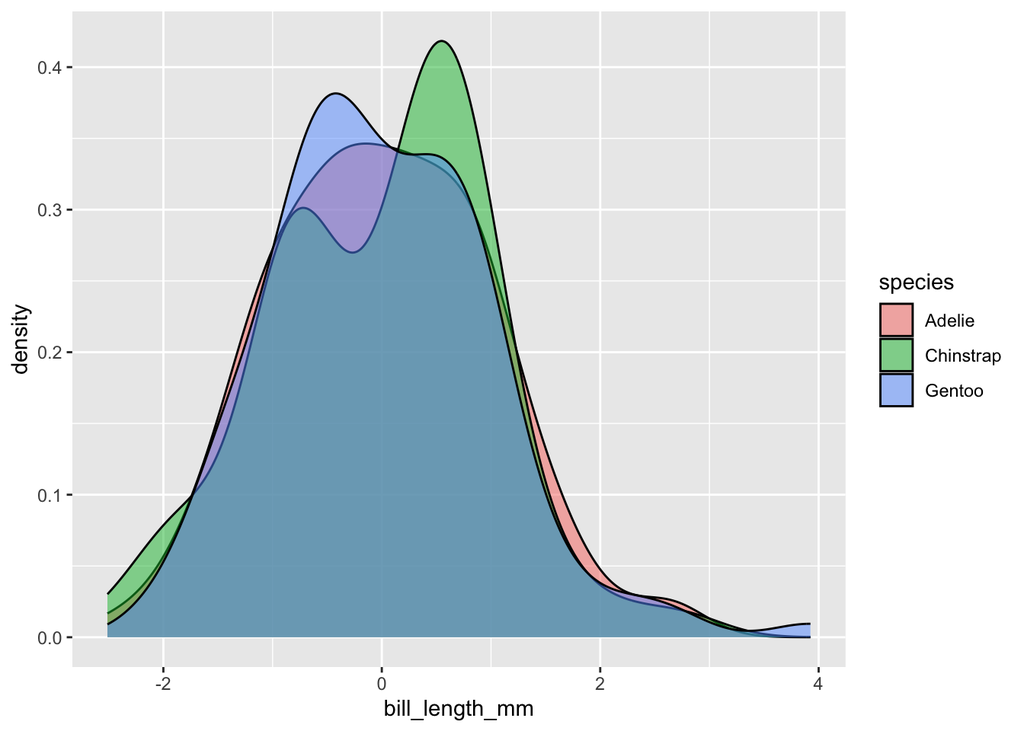

```r
palmerpenguins::penguins |>
  mutate(
    bill_length_mm = scale(bill_length_mm),
    .by = species) |>
  ggplot() +
  geom_density(aes(x = bill_length_mm, fill = species),
               alpha = 0.5)
```

Another option to depict density distribution. Non centered

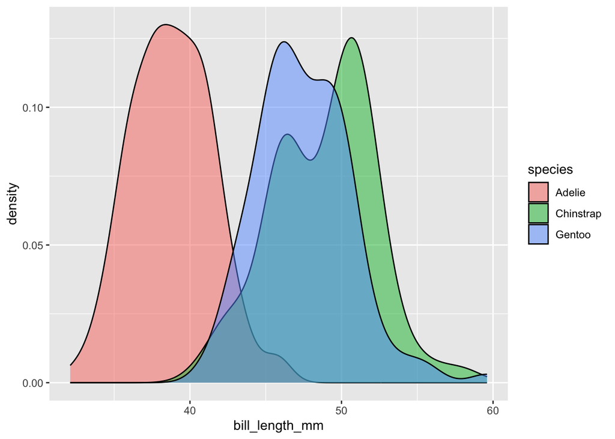

```r
palmerpenguins::penguins |>
  # mutate(
  #   bill_length_mm = scale(bill_length_mm),
  #   .by = species) |>
  ggplot() +
  geom_density(aes(x = bill_length_mm, fill = species),
               alpha = 0.5)
```

## Lesson 7

### Missing data with group calculations

Notice not all combinations between species and islands are displayed. For instance Gentoe - Togerson, Chinstrap - Biscoe are not displayed.

```r
penguins_wo_NAs |>
  summarise(
    mean_flipper_length = mean(flipper_length_mm, na.rm = TRUE),
    sd_flipper_length = sd(flipper_length_mm, na.rm = TRUE),
    flipper_lengths = list(flipper_length_mm),
    .by = c(species,island) )
```

```
# A tibble: 5 × 5
  species   island    mean_flipper_length sd_flipper_length flipper_lengths
  <fct>     <fct>                   <dbl>             <dbl> <list>
1 Adelie    Torgersen                192.              6.22 <int [47]>
2 Adelie    Biscoe                   189.              6.73 <int [44]>
3 Adelie    Dream                    190.              6.48 <int [55]>
4 Gentoo    Biscoe                   217.              6.59 <int [119]>
5 Chinstrap Dream                    196.              7.13 <int [68]>
```

To display all combinations between species and islands, even for those combinations with no observations we could use the following `complete()` function.

`complete()` allows to display all combinations among variables with missing data. I also allows to change the default `NA` value for another, say 0.

```r
penguins_wo_NAs |>
  summarise(
    mean_flipper_length = mean(flipper_length_mm, na.rm = TRUE),
    sd_flipper_length = sd(flipper_length_mm, na.rm = TRUE),
    flipper_lengths = list(flipper_length_mm),
    .by = c(species,island) ) |>
  complete(
    species, island,
    fill = list(mean_flipper_length = 0,
                sd_flipper_length = 0)
  )
```

```
# A tibble: 9 × 5
  species   island    mean_flipper_length sd_flipper_length flipper_lengths
  <fct>     <fct>                   <dbl>             <dbl> <list>
1 Adelie    Biscoe                   189.              6.73 <int [44]>
2 Adelie    Dream                    190.              6.48 <int [55]>
3 Adelie    Torgersen                192.              6.22 <int [47]>
4 Chinstrap Biscoe                     0               0    <NULL>
5 Chinstrap Dream                    196.              7.13 <int [68]>
6 Chinstrap Torgersen                  0               0    <NULL>
7 Gentoo    Biscoe                   217.              6.59 <int [119]>
8 Gentoo    Dream                      0               0    <NULL>
9 Gentoo    Torgersen                  0               0    <NULL>
```

## Lesson 8

### Using across() + mutate() instead of repetitions.

Original mutate

```r
penguins_wo_NAs |>
  summarise(
    mean_bill_depth = mean(bill_depth_mm),
    mean_bill_length = mean(bill_length_mm),
    mean_flipper_length = mean(flipper_length_mm),
    mean_body_mass = mean(body_mass_g))
```

```
# A tibble: 1 × 4
  mean_bill_depth mean_bill_length mean_flipper_length mean_body_mass
            <dbl>            <dbl>               <dbl>          <dbl>
1            17.2             44.0                201.          4207.
```

#### Using ’across()` function. Several variations.

Also using glue() to affix a name to the corresponding output

Notice the output does not display the prefix `mean_`. If you want it you need the option `.names` that it is a glue specification.

```r
library(glue)

#Long option
penguins_wo_NAs |>
  summarise(across(
    .cols = c("bill_length_mm",
              "bill_depth_mm",
              "flipper_length_mm",
              "body_mass_g"),
    .fns = mean,
    .names = 'mean_{.col}'
  ))
```

```
# A tibble: 1 × 4
  mean_bill_length_mm mean_bill_depth_mm mean_flipper_length_mm mean_body_mass_g
                <dbl>              <dbl>                  <dbl>            <dbl>
1                44.0               17.2                   201.            4207.
```

```r
#Columns option
penguins_wo_NAs |>
  summarise(across(.cols = 3:6,
                   function(x) mean(x, na.rm = TRUE),
                   .names = 'mean_{.col}'))
```

```
# A tibble: 1 × 4
  mean_bill_length_mm mean_bill_depth_mm mean_flipper_length_mm mean_body_mass_g
                <dbl>              <dbl>                  <dbl>            <dbl>
1                44.0               17.2                   201.            4207.
```

```r
#where(is.numeric)
penguins_wo_NAs |>
  summarise(across(where(is.numeric),
                   function(x) mean(x, na.rm = TRUE),
                   .names = 'mean_{.col}') )
```

```
# A tibble: 1 × 5
  mean_bill_length_mm mean_bill_depth_mm mean_flipper_length_mm mean_body_mass_g
                <dbl>              <dbl>                  <dbl>            <dbl>
1                44.0               17.2                   201.            4207.
# ℹ 1 more variable: mean_year <dbl>
```

```r
#Selecting columns with specific names
penguins_wo_NAs |>
  summarise(across(contains('bill'),
                   function(x) mean(x, na.rm = TRUE),
                   .names = 'mean_{.col}') )
```

```
# A tibble: 1 × 2
  mean_bill_length_mm mean_bill_depth_mm
                <dbl>              <dbl>
1                44.0               17.2
```

```r
#Selecting columns with specific names
penguins_wo_NAs |>
  summarise(across(starts_with('flipper'),
                   function(x) mean(x, na.rm = TRUE),
                   .names = 'mean_{.col}') )
```

```
# A tibble: 1 × 1
  mean_flipper_length_mm
                   <dbl>
1                   201.
```

#### Removing unwanted strings

Note that we could remove unwanted strings such as `_mm` and `_g`.

```r
penguins_wo_NAs |>
  summarise(across(
    .cols = c("bill_length_mm",
              "bill_depth_mm",
              "flipper_length_mm",
              "body_mass_g"),
    .fns = mean,
    .names = 'mean_{.col |> str_remove("_mm") |> str_remove("_g")}'
  ))
```

```
# A tibble: 1 × 4
  mean_bill_length mean_bill_depth mean_flipper_length mean_body_mass
             <dbl>           <dbl>               <dbl>          <dbl>
1             44.0            17.2                201.          4207.
```

Another option is to include the .fn in the names function. But unfortunately it did not do the trick because the prefix mean was removed. Instead a prexif `1_` was added .

```r
penguins_wo_NAs |>
  summarise(across(
    .cols = c("bill_length_mm",
              "bill_depth_mm",
              "flipper_length_mm",
              "body_mass_g"),
    .fns = mean,
    .names = '{.fn}_{.col |> str_remove("_mm") |> str_remove("_g")}'
  ))
```

```
# A tibble: 1 × 4
  `1_bill_length` `1_bill_depth` `1_flipper_length` `1_body_mass`
            <dbl>          <dbl>              <dbl>         <dbl>
1            44.0           17.2               201.         4207.
```

To make it work correctly, we need to use .fns = list(mean = mean).

```r
penguins_wo_NAs |>
  summarise(across(
    .cols = c("bill_length_mm",
              "bill_depth_mm",
              "flipper_length_mm",
              "body_mass_g"),
    .fns = list(avg = mean),
    .names = '{.fn}_{.col |> str_remove("_mm") |> str_remove("_g")}'
  ))
```

```
# A tibble: 1 × 4
  avg_bill_length avg_bill_depth avg_flipper_length avg_body_mass
            <dbl>          <dbl>              <dbl>         <dbl>
1            44.0           17.2               201.         4207.
```

You can compute more summary statistics

```r
penguins_wo_NAs |>
  summarise(across(
    .cols = c("bill_length_mm",
              "bill_depth_mm",
              "flipper_length_mm",
              "body_mass_g"),
    .fns = list(avg = mean, standard_deviation = sd),
    .names = '{.fn}_{.col |> str_remove("_mm") |> str_remove("_g")}'
  ))
```

```
# A tibble: 1 × 8
  avg_bill_length standard_deviation_bil…¹ avg_bill_depth standard_deviation_b…²
            <dbl>                    <dbl>          <dbl>                  <dbl>
1            44.0                     5.47           17.2                   1.97
# ℹ abbreviated names: ¹standard_deviation_bill_length,
#   ²standard_deviation_bill_depth
# ℹ 4 more variables: avg_flipper_length <dbl>,
#   standard_deviation_flipper_length <dbl>, avg_body_mass <dbl>,
#   standard_deviation_body_mass <dbl>
```

## Lesson 9

### Using across() + mutate( ) instead of repetitions

Using across() inside mutate() facilitates cleaning multiple columns in one single shot. In this example, we would be using across() along with the parse_number() to extract the first number inside a text.

We get a warning but the numbers were parsed or extracted from the strings. The end result is a tibble table with numbers instead of characters.

```r
tibble(
  text1 = c("I have 10 apples", "I have 20 appples"),
  text2 = c("I have 30 apples", "I have 40 apples")
) |>
  mutate(
    across(
      .cols = everything(),
      .fns = parse_number
    )
  )
```

```
# A tibble: 2 × 2
  text1 text2
  <dbl> <dbl>
1    10    30
2    20    40
```

If you want to include both numbers and text, you need to add a new column as follows:

```r
tibble(
  text1 = c("I have 10 apples", "I have 20 appples"),
  text2 = c("I have 30 apples", "I have 40 apples")
) |>
  mutate(
    across(
      .cols = everything(),
      .fns = parse_number,
      .names = "number_{.col}"
    )
  )
```

```
# A tibble: 2 × 4
  text1             text2            number_text1 number_text2
  <chr>             <chr>                   <dbl>        <dbl>
1 I have 10 apples  I have 30 apples           10           30
2 I have 20 appples I have 40 apples           20           40
```

## Lesson 10

### Adding calculations next to across()

Recapping a prior example below. The operations listed after summarize is just one of the calculations that could be further added

```r
penguins_wo_NAs |>
  summarise(across(
    .cols = c("bill_length_mm",
              "bill_depth_mm",
              "flipper_length_mm",
              "body_mass_g"),
    .fns = mean,
    .names = 'mean_{.col |> str_remove("_mm")}'
  ))
```

```
# A tibble: 1 × 4
  mean_bill_length mean_bill_depth mean_flipper_length mean_body_mass_g
             <dbl>           <dbl>               <dbl>            <dbl>
1             44.0            17.2                201.            4207.
```

Adding more operations to summarise(). Say you want to add a standard deviation, say sd for mean_bill_length. All what you need to do is to add a line.

```r
penguins_wo_NAs |>
  summarise(across(
    .cols = c("bill_length_mm",
              "bill_depth_mm",
              "flipper_length_mm",
              "body_mass_g"),
    .fns = mean,
    .names = 'mean_{.col |> str_remove("_mm")}'
  ),
  sd_bill_length = sd(bill_length_mm)
  )
```

```
# A tibble: 1 × 5
  mean_bill_length mean_bill_depth mean_flipper_length mean_body_mass_g
             <dbl>           <dbl>               <dbl>            <dbl>
1             44.0            17.2                201.            4207.
# ℹ 1 more variable: sd_bill_length <dbl>
```

## Lesson 11

### Grouped calculations with across()

In the last lesson we learned that not only we can use across() for multiple computations, but also we can combine it with other analyses. This means we could do across calculations on a group basis as well. In short, we can perform powerful estimations in a concise manner.

```r
penguins_wo_NAs |>
  summarise(across(
    .cols = c("bill_length_mm",
              "bill_depth_mm",
              "flipper_length_mm",
              "body_mass_g"),
    .fns = mean,
    .names = 'mean_{.col |> str_remove("_mm")}'
  ),
  sd_bill_length = sd(bill_length_mm),
  .by = c(species,island)
  )
```

```
# A tibble: 5 × 7
  species   island    mean_bill_length mean_bill_depth mean_flipper_length
  <fct>     <fct>                <dbl>           <dbl>               <dbl>
1 Adelie    Torgersen             39.0            18.5                192.
2 Adelie    Biscoe                39.0            18.4                189.
3 Adelie    Dream                 38.5            18.2                190.
4 Gentoo    Biscoe                47.6            15.0                217.
5 Chinstrap Dream                 48.8            18.4                196.
# ℹ 2 more variables: mean_body_mass_g <dbl>, sd_bill_length <dbl>
```

An extension of this idea also apply to names =. See below

```r
penguins_wo_NAs |>
  summarise(across(
    .cols = c("bill_length_mm",
              "bill_depth_mm",
              "flipper_length_mm",
              "body_mass_g"),
    .fns = list(avg = mean, standard_deviation = sd),
    .names = '{.fn}_{.col |> str_remove("_mm") |> str_remove("_g")}'
  ),
  sd_bill_lenght = sd(bill_length_mm),
  .by = c(species,island))
```

```
# A tibble: 5 × 11
  species   island    avg_bill_length standard_deviation_bill_l…¹ avg_bill_depth
  <fct>     <fct>               <dbl>                       <dbl>          <dbl>
1 Adelie    Torgersen            39.0                        3.03           18.5
2 Adelie    Biscoe               39.0                        2.48           18.4
3 Adelie    Dream                38.5                        2.48           18.2
4 Gentoo    Biscoe               47.6                        3.11           15.0
5 Chinstrap Dream                48.8                        3.34           18.4
# ℹ abbreviated name: ¹standard_deviation_bill_length
# ℹ 6 more variables: standard_deviation_bill_depth <dbl>,
#   avg_flipper_length <dbl>, standard_deviation_flipper_length <dbl>,
#   avg_body_mass <dbl>, standard_deviation_body_mass <dbl>,
#   sd_bill_lenght <dbl>
```

## Lesson 12

### Getting to know The `reframe()` function

`reframe()` is a function sitting between mutate and summarize. This function has an arbitrary length between one, which is associated with `summarise()` and multiple, which is associated with `mutate()`.

The `range()` function is relevant. It tells you the minimum and maximum values of a column.

```r
range(penguins_wo_NAs$bill_length_mm)
```

```
[1] 32.1 59.6
```

```r
penguins_wo_NAs |>
  summarise(range_bill_lenght_mm = range(bill_length_mm))
```

```
# A tibble: 2 × 1
  range_bill_lenght_mm
                 <dbl>
1                 32.1
2                 59.6
```

```r
#Using reframe() function instead of summarise()
penguins_wo_NAs |>
  reframe(range_bill_lenght_mm = range(bill_length_mm))
```

```
# A tibble: 2 × 1
  range_bill_lenght_mm
                 <dbl>
1                 32.1
2                 59.6
```

Since `reframe()` along `range()` would return unnamed results, we could add `type()` for adding the labels to be added into the output.

```r
penguins_wo_NAs |>
  reframe(
    type = c("min", "max"),
    range_bill_lenght_mm = range(bill_length_mm))
```

```
# A tibble: 2 × 2
  type  range_bill_lenght_mm
  <chr>                <dbl>
1 min                   32.1
2 max                   59.6
```

We can do more things with reframe(). We can use group statistics.

```r
penguins_wo_NAs |>
  reframe(
    type = c("min", "max"),
    range_bill_lenght_mm = range(bill_length_mm),
    .by = species)
```

```
# A tibble: 6 × 3
  species   type  range_bill_lenght_mm
  <fct>     <chr>                <dbl>
1 Adelie    min                   32.1
2 Adelie    max                   46
3 Gentoo    min                   40.9
4 Gentoo    max                   59.6
5 Chinstrap min                   40.9
6 Chinstrap max                   58
```

We can also add across() and request range() within .fns =

```r
penguins_wo_NAs |>
  reframe(
    type = c("min", "max"),
    across(.cols = c("bill_length_mm",
              "bill_depth_mm",
              "flipper_length_mm",
              "body_mass_g"),
           .fns = range
             ),
    .by = species)
```

```
# A tibble: 6 × 6
  species   type  bill_length_mm bill_depth_mm flipper_length_mm body_mass_g
  <fct>     <chr>          <dbl>         <dbl>             <int>       <int>
1 Adelie    min             32.1          15.5               172        2850
2 Adelie    max             46            21.5               210        4775
3 Gentoo    min             40.9          13.1               203        3950
4 Gentoo    max             59.6          17.3               231        6300
5 Chinstrap min             40.9          16.4               178        2700
6 Chinstrap max             58            20.8               212        4800
```

But we could also format it as a table. To do, we need to call upon pivot _longer and pivot_wider

```r
#Pivot longer
penguins_wo_NAs |>
  reframe(
    type = c("min", "max"),
    across(.cols = c("bill_length_mm",
              "bill_depth_mm",
              "flipper_length_mm",
              "body_mass_g"),
           .fns = range
             ),
    .by = species) |>
  pivot_longer(
    cols = -c(1:2),
    names_to = "quantity",
    values_to = 'value'
  ) |>
  pivot_wider(
    id_cols = c(quantity),
    names_from = c(species,type),
    values_from = value
  )
```

```
# A tibble: 4 × 7
  quantity          Adelie_min Adelie_max Gentoo_min Gentoo_max Chinstrap_min
  <chr>                  <dbl>      <dbl>      <dbl>      <dbl>         <dbl>
1 bill_length_mm          32.1       46         40.9       59.6          40.9
2 bill_depth_mm           15.5       21.5       13.1       17.3          16.4
3 flipper_length_mm      172        210        203        231           178
4 body_mass_g           2850       4775       3950       6300          2700
# ℹ 1 more variable: Chinstrap_max <dbl>
```

## Lesson 13

Motivation for tidyselect helpers. They are powerful techniques. Allows one to select the correct columns or variables. For instance, the `.fns =` allows one to label the variables. Then this label is collected via the `.names =` function (see below)

```r
penguins_wo_NAs |>
  summarise(across(
    .cols = c("bill_length_mm",
              "bill_depth_mm",
              "flipper_length_mm",
              "body_mass_g"),
    #Adding new labels
    .fns = list(avg = mean, standard_deviation = sd),
    .names = '{.fn}_{.col |> str_remove("_mm")}'
  ),
  .by = c(species,island))
```

```
# A tibble: 5 × 10
  species   island    avg_bill_length standard_deviation_bill_l…¹ avg_bill_depth
  <fct>     <fct>               <dbl>                       <dbl>          <dbl>
1 Adelie    Torgersen            39.0                        3.03           18.5
2 Adelie    Biscoe               39.0                        2.48           18.4
3 Adelie    Dream                38.5                        2.48           18.2
4 Gentoo    Biscoe               47.6                        3.11           15.0
5 Chinstrap Dream                48.8                        3.34           18.4
# ℹ abbreviated name: ¹standard_deviation_bill_length
# ℹ 5 more variables: standard_deviation_bill_depth <dbl>,
#   avg_flipper_length <dbl>, standard_deviation_flipper_length <dbl>,
#   avg_body_mass_g <dbl>, standard_deviation_body_mass_g <dbl>
```

Instead of listing the columns where the means and standard deviations are to be computed, we could use tidy helpers to facilitate locating them. The tidyselect to be used is `where`. It works in combination with another function, `is.numeric()`, that finds the desired property of the column or variable.

```r
penguins_wo_NAs |>
  summarise(across(
    .cols = where(is.numeric),
    .fns = list(avg = mean),
    .names = '{.fn}_{.col |> str_remove("_mm")}'
  ),
  .by = c(species,island))
```

```
# A tibble: 5 × 7
  species   island    avg_bill_length avg_bill_depth avg_flipper_length
  <fct>     <fct>               <dbl>          <dbl>              <dbl>
1 Adelie    Torgersen            39.0           18.5               192.
2 Adelie    Biscoe               39.0           18.4               189.
3 Adelie    Dream                38.5           18.2               190.
4 Gentoo    Biscoe               47.6           15.0               217.
5 Chinstrap Dream                48.8           18.4               196.
# ℹ 2 more variables: avg_body_mass_g <dbl>, avg_year <dbl>
```

Notice this omnibus statement includes the column year, which is categorical. In other to exclude this kind of variable from the omnibus statement we can add the `-`(minus) to exclude the categorical variable. Notice we need to encircle it within the concatenate function c( ). `c(where(is.numeric), -year)` concatenates the tidy helper while excluding the column year.

```r
penguins_wo_NAs |>
  summarise(across(
    .cols = c(where(is.numeric), -year),
    .fns = list(avg = mean),
    .names = '{.fn}_{.col |> str_remove("_mm")}'
  ),
  .by = c(species,island))
```

```
# A tibble: 5 × 6
  species   island    avg_bill_length avg_bill_depth avg_flipper_length
  <fct>     <fct>               <dbl>          <dbl>              <dbl>
1 Adelie    Torgersen            39.0           18.5               192.
2 Adelie    Biscoe               39.0           18.4               189.
3 Adelie    Dream                38.5           18.2               190.
4 Gentoo    Biscoe               47.6           15.0               217.
5 Chinstrap Dream                48.8           18.4               196.
# ℹ 1 more variable: avg_body_mass_g <dbl>
```

## Lesson 14

Another custom function for `across()` function. Using the original penguins dataset. Performing the function, you will get missing data.

How to avoid these situations of ending up with `NA`s. We can use the mean function with `na.rm` option. The way to do so is to specify a new function that also specifies na.rm = TRUE. We can do so via an anonymous `function(x)`

Two options:

```r
#Option 1: removing NAs within the mean function
palmerpenguins::penguins |>
  summarise(across(
    .cols = c(where(is.numeric), -year),
    .fns = function(x) mean(x, na.rm = TRUE),
    .names = 'mean_{.col |> str_remove("_mm")}'
  ),
  .by = c(species,island))
```

```
# A tibble: 5 × 6
  species   island    mean_bill_length mean_bill_depth mean_flipper_length
  <fct>     <fct>                <dbl>           <dbl>               <dbl>
1 Adelie    Torgersen             39.0            18.4                191.
2 Adelie    Biscoe                39.0            18.4                189.
3 Adelie    Dream                 38.5            18.3                190.
4 Gentoo    Biscoe                47.5            15.0                217.
5 Chinstrap Dream                 48.8            18.4                196.
# ℹ 1 more variable: mean_body_mass_g <dbl>
```

```r
#Option 2: removing NAs in the function
palmerpenguins::penguins |>
  summarise(across(
    .cols = c(where(is.numeric), -year),
    .fns = \(x) mean(x, na.rm = TRUE),
    .names = 'mean_{.col |> str_remove("_mm")}'
  ),
  .by = c(species,island))
```

```
# A tibble: 5 × 6
  species   island    mean_bill_length mean_bill_depth mean_flipper_length
  <fct>     <fct>                <dbl>           <dbl>               <dbl>
1 Adelie    Torgersen             39.0            18.4                191.
2 Adelie    Biscoe                39.0            18.4                189.
3 Adelie    Dream                 38.5            18.3                190.
4 Gentoo    Biscoe                47.5            15.0                217.
5 Chinstrap Dream                 48.8            18.4                196.
# ℹ 1 more variable: mean_body_mass_g <dbl>
```

```r
#Option 3 creating a prefix for the new variables

palmerpenguins::penguins |>
  summarise(across(
    .cols = c(where(is.numeric), -year),
    .fns = list(avg = function(x) mean(x, na.rm = TRUE)),
    .names = '{.fn}_{.col |> str_remove("_mm")}'
  ),
  .by = c(species,island))
```

```
# A tibble: 5 × 6
  species   island    avg_bill_length avg_bill_depth avg_flipper_length
  <fct>     <fct>               <dbl>          <dbl>              <dbl>
1 Adelie    Torgersen            39.0           18.4               191.
2 Adelie    Biscoe               39.0           18.4               189.
3 Adelie    Dream                38.5           18.3               190.
4 Gentoo    Biscoe               47.5           15.0               217.
5 Chinstrap Dream                48.8           18.4               196.
# ℹ 1 more variable: avg_body_mass_g <dbl>
```

## Lesson 15

Selecting the right data by column/variable types. Using select along with `where(is.numeric)` screens the database in search of variables that are numeric. We can eliminate as well variable with are not numeric.

The `where()` function can be used in several scenarios.

```r
penguins_wo_NAs |>
  select(where(is.numeric), -year)
```

```
# A tibble: 333 × 4
   bill_length_mm bill_depth_mm flipper_length_mm body_mass_g
            <dbl>         <dbl>             <int>       <int>
 1           39.1          18.7               181        3750
 2           39.5          17.4               186        3800
 3           40.3          18                 195        3250
 4           36.7          19.3               193        3450
 5           39.3          20.6               190        3650
 6           38.9          17.8               181        3625
 7           39.2          19.6               195        4675
 8           41.1          17.6               182        3200
 9           38.6          21.2               191        3800
10           34.6          21.1               198        4400
# ℹ 323 more rows
```

```r
#* Using where() for selecting character variables. For penguins database the
#* characters were defined as factor

penguins_wo_NAs |>
  select(where(is.factor))
```

```
# A tibble: 333 × 3
   species island    sex
   <fct>   <fct>     <fct>
 1 Adelie  Torgersen male
 2 Adelie  Torgersen female
 3 Adelie  Torgersen female
 4 Adelie  Torgersen female
 5 Adelie  Torgersen male
 6 Adelie  Torgersen female
 7 Adelie  Torgersen male
 8 Adelie  Torgersen female
 9 Adelie  Torgersen male
10 Adelie  Torgersen male
# ℹ 323 more rows
```

```r
#* For selecting factor and character variables use the following

penguins_wo_NAs |>
  select(where(is.factor), where(is.character))
```

```
# A tibble: 333 × 3
   species island    sex
   <fct>   <fct>     <fct>
 1 Adelie  Torgersen male
 2 Adelie  Torgersen female
 3 Adelie  Torgersen female
 4 Adelie  Torgersen female
 5 Adelie  Torgersen male
 6 Adelie  Torgersen female
 7 Adelie  Torgersen male
 8 Adelie  Torgersen female
 9 Adelie  Torgersen male
10 Adelie  Torgersen male
# ℹ 323 more rows
```

Alternatively, you can define a custom function. Inside the `where()` function you can use the anonymous function. Combine the two with an or ||. Consequently the defined function is TRUE if the corresponding column/variable is a factor or a character. If numeric, it would yield a FALSE.

```r
penguins_wo_NAs |>
  select(where(function(x) is.factor(x) || is.character(x)) )
```

```
# A tibble: 333 × 3
   species island    sex
   <fct>   <fct>     <fct>
 1 Adelie  Torgersen male
 2 Adelie  Torgersen female
 3 Adelie  Torgersen female
 4 Adelie  Torgersen female
 5 Adelie  Torgersen male
 6 Adelie  Torgersen female
 7 Adelie  Torgersen male
 8 Adelie  Torgersen female
 9 Adelie  Torgersen male
10 Adelie  Torgersen male
# ℹ 323 more rows
```

Defining custom function to identify numeric columns. And we could add another condition such as identifying the mean to be above a particular value.

So here we defined an anonymous function that checks whether a variable is numeric and where the mean of the variable is above 200.

The difference between the double && and the single & operator is that the single operator generates a warning message. The argument is not numeric or logical.

```r
penguins_wo_NAs |>
  select(where(function(x) is.numeric(x) && mean(x) > 200 ) )
```

```
# A tibble: 333 × 3
   flipper_length_mm body_mass_g  year
               <int>       <int> <int>
 1               181        3750  2007
 2               186        3800  2007
 3               195        3250  2007
 4               193        3450  2007
 5               190        3650  2007
 6               181        3625  2007
 7               195        4675  2007
 8               182        3200  2007
 9               191        3800  2007
10               198        4400  2007
# ℹ 323 more rows
```

Another handy option is to get columns where specific percentage of values are missing. In this case asking for variables with more than 1% of missing cases.

It usually practical to name this function for future use.

```r
palmerpenguins::penguins |>
  select(where(function(x) mean(is.na(x)) > 0.01) )
```

```
# A tibble: 344 × 1
   sex
   <fct>
 1 male
 2 female
 3 female
 4 <NA>
 5 female
 6 male
 7 female
 8 male
 9 <NA>
10 <NA>
# ℹ 334 more rows
```

```r
#Creating function
more_than_one_percent_missing <- function(x) mean(is.na(x)) > 0.01

#Using function

palmerpenguins::penguins |>
  select(where(more_than_one_percent_missing ))
```

```
# A tibble: 344 × 1
   sex
   <fct>
 1 male
 2 female
 3 female
 4 <NA>
 5 female
 6 male
 7 female
 8 male
 9 <NA>
10 <NA>
# ℹ 334 more rows
```

## Lesson 16

Select the right data by column name

1. Selecting consecutive columns. Between bill_length and sex column
2. Selecting columns by specific variable’s labels. Selecting variables ending with `_mm`
3. Selecting columns with start with a particular string. Selecting variables starting with `bill`.
4. Selecting columns that contain similar strings. Selecting variables with the string `lenght`

```r
#Selecting consecutive columns
penguins_wo_NAs |>
  select(bill_length_mm:sex)
```

```
# A tibble: 333 × 5
   bill_length_mm bill_depth_mm flipper_length_mm body_mass_g sex
            <dbl>         <dbl>             <int>       <int> <fct>
 1           39.1          18.7               181        3750 male
 2           39.5          17.4               186        3800 female
 3           40.3          18                 195        3250 female
 4           36.7          19.3               193        3450 female
 5           39.3          20.6               190        3650 male
 6           38.9          17.8               181        3625 female
 7           39.2          19.6               195        4675 male
 8           41.1          17.6               182        3200 female
 9           38.6          21.2               191        3800 male
10           34.6          21.1               198        4400 male
# ℹ 323 more rows
```

```r
#Selecting columns ending with _mm
penguins_wo_NAs |>
  select(ends_with('_mm'))
```

```
# A tibble: 333 × 3
   bill_length_mm bill_depth_mm flipper_length_mm
            <dbl>         <dbl>             <int>
 1           39.1          18.7               181
 2           39.5          17.4               186
 3           40.3          18                 195
 4           36.7          19.3               193
 5           39.3          20.6               190
 6           38.9          17.8               181
 7           39.2          19.6               195
 8           41.1          17.6               182
 9           38.6          21.2               191
10           34.6          21.1               198
# ℹ 323 more rows
```

```r
#Selecting columns starting with bill
penguins_wo_NAs |>
  select(starts_with('bill'))
```

```
# A tibble: 333 × 2
   bill_length_mm bill_depth_mm
            <dbl>         <dbl>
 1           39.1          18.7
 2           39.5          17.4
 3           40.3          18
 4           36.7          19.3
 5           39.3          20.6
 6           38.9          17.8
 7           39.2          19.6
 8           41.1          17.6
 9           38.6          21.2
10           34.6          21.1
# ℹ 323 more rows
```

```r
#Selecting columns the string lenght
penguins_wo_NAs |>
  select(contains('length'))
```

```
# A tibble: 333 × 2
   bill_length_mm flipper_length_mm
            <dbl>             <int>
 1           39.1               181
 2           39.5               186
 3           40.3               195
 4           36.7               193
 5           39.3               190
 6           38.9               181
 7           39.2               195
 8           41.1               182
 9           38.6               191
10           34.6               198
# ℹ 323 more rows
```